Statistics of extremes · manuscript draft

# Composite M-quantile estimation for extreme-value models under body misspecification

A tail-weighted loss buys a real reduction in far-tail error when the body of the distribution is wrong, and costs 12–32% when it is not. Both numbers matter, and the standard comparison reports only the first.

## Abstract

Extreme-value models are justified asymptotically but fitted at finite block sizes and thresholds, where the family is typically adequate in the tail and wrong in the body. Global criteria — likelihood, L-moments — distribute that misspecification across the whole distribution and bias the extrapolation of interest. We study estimators that integrate an asymmetric loss over probability levels against a measure concentrated in the tail, place them in the M-quantile family, and give their asymptotic distribution: the criterion's first-order condition makes the estimator a Z-estimator whose score is itself an integral over levels, so a sandwich applies in which the Hessian term carries the level-by-level misspecification discrepancy and the middle term is a weighted double integral of a covariance kernel across levels — for the pinball loss, the covariance of the Brownian bridge. Replacing the pinball loss of the composite quantile estimator by its asymmetric-least-squares analogue reduces mean squared error at the 1000-year return level by a factor of two to six, at the cost of a structural obstacle: the expectile identification equation contains the distribution's mean, so no weight makes the estimator asymptotically unbiased under body contamination. A one-sided inverted-Huber influence function removes the mean exactly, giving a functional that depends on the distribution only above a knot, and it is the most accurate far-tail member of the family at n = 100 — though the asymptotics show that advantage to be a finite-sample one rather than a property of the functional. Against that, we report what the approach costs when the model is correct — 12–32% in the far tail of a correctly specified GEV, more at short return periods, with bias in the unsafe direction — and show that 68% of the apparent gain over peaks-over-threshold in a misspecified study is present with no misspecification at all, because the conventional reference discards nine tenths of the sample. Compared directly against a tail-weighted likelihood, the composite criteria lead when fitting a generalized Pareto tail above a known threshold and trail when fitting a generalized extreme value distribution to block maxima, which we read as efficiency recovered on a poorly identified problem rather than as a verdict on either construction. Finally, penultimate approximation gives the construction an *effective threshold* — the return period whose local penultimate shape equals what the estimator returns — which turns the weight into a quantity a hydrologist can argue with, prices it against the asymptotic variance, and shows that most of the reach comes from the choice of matched functional rather than from the tail weighting.

**Keywords:** tail robustness · expectiles · M-quantiles · penultimate approximation · sandwich variance · generalized extreme value · generalized Pareto · return level · model misspecification · flood frequency

## 1Introduction

Extreme-value practice rests on two limit theorems. Block maxima converge to the generalized extreme value (GEV) family; exceedances over a high threshold converge to the generalized Pareto (GPD). Both are statements about a limit, and both are applied at finite block sizes and finite thresholds, where convergence is incomplete. The resulting misspecification is not uniform across the distribution. In a great many applications the fitted family is a reasonable description of the upper tail and a poor description of the body, because the body is generated by a different physical mechanism.

Rain-on-snow flooding is a clean instance, and the mixed-process view of it is long established: Waylen and Woo (1982) modelled annual floods in a Cascade Mountains catchment as the maximum of a rainfall-generated and a snowmelt-generated series, and fitted the two separately. Annual maxima at such a catchment are drawn from two populations — ordinary snowmelt freshets, moderate and tightly clustered, and rain-on-snow events, rare and heavy — so the maximum of the two has a tail governed by the rain-driven mechanism and a body governed by the snowmelt one. A single GEV cannot describe both, and a criterion that weights all parts of the distribution equally — maximum likelihood, or L-moments — spends its fit reconciling them. The cost falls on the extrapolation that the analysis exists to produce.

The literature offers three responses. *Threshold selection* discards the body entirely, trading bias for the variance of a smaller sample. *Robust estimation* bounds the influence of individual observations: Dupuis (1998) and Juárez and Schucany (2004) for the GPD, and the minimum density power divergence estimator of Basu et al. (1998), which is indexed by a constant running from maximum likelihood at zero to bounded influence above it. That family shares the elastile's structure — a single dial from efficient to robust — but runs in the opposite direction, downweighting large observations as contamination where the tail problem treats them as signal. The third response, and the one this paper belongs to, is *tail-robustness*: weight the fitting criterion towards the tail so that contamination in the body does not propagate into the extrapolation. Fung (2022) proves that a weighted likelihood of this kind yields a consistent tail index under model misspecification, motivated by insurance claim severities.

A fourth response deserves separate mention because it addresses a different failure. The convergence of normalised maxima to a GEV limit can be extremely slow — famously so for a normal parent — and Fisher and Tippett (1928) observed that approximating instead by a *sequence* of extreme-value distributions with shape ξ<sub>n</sub> → ξ improves the approximation substantially. These penultimate approximations (Gomes and de Haan, 1999) correct the tail model itself at finite block size or threshold, whereas the body-misspecification problem takes the tail model as given and asks how to stop the body corrupting its fit. The two are complementary rather than competing: Section 6 uses penultimate approximation to say what level a tail-weighted criterion is effectively reading, and Section 7 returns to what a combined treatment would require.

We study a different construction in the same spirit. Rather than weighting observations, we integrate an asymmetric loss over *probability levels*, against a measure concentrated near one. With the pinball loss this gives the composite quantile estimator, which is asymptotically unbiased under body contamination but suffers a severe variance penalty in the far tail. The asymmetric-least-squares analogue — the composite *expectile* estimator — has not been examined, and it is the natural candidate: expectiles use the magnitudes of observations rather than their ranks, which is where the information about the shape parameter lives.

The paper makes five contributions. Section 2 defines the composite M-quantile family and shows that its members, including a convex combination of the two losses, are M-quantiles in the sense of Breckling and Chambers (1988), with closed-form identification equations for the GEV and GPD; it also gives the family's asymptotic distribution, which is a sandwich whose Hessian term carries the level-by-level misspecification discrepancy and whose middle term is a weighted double integral of a covariance kernel across levels. Section 3 characterises when the criterion is well posed: which weights are admissible, and which moment conditions each loss requires. Section 4 establishes the central obstacle — the expectile is anchored to the distribution's mean, so no weight removes body contamination asymptotically — and gives an influence function that removes it structurally. Section 5 reports a simulation study designed to separate what the criterion contributes from what the comparison contributes, and finds that most of the apparent advantage over conventional practice is the latter. Section 6 gives the construction an *effective threshold* and prices it against the asymptotic variance, which turns the weight into a quantity with hydrological meaning and reverses two of the finite-sample readings.

## 2The composite M-quantile family

### 2.1The criterion

Let `T(p|θ)` denote a level-p functional of a parametric family indexed by θ — its quantile function, expectile function, or another member of the family below. Let w be a weight on (0, 1), non-negative and integrable. Given observations y₁, …, yₙ we minimise

S(θ) = Σ <sub>i</sub> ∫₀¹ w(p) |p − I(y <sub>i</sub> < T(p|θ))| ρ(y <sub>i</sub> − T(p|θ)) dp

(1)

with ρ(u) = |u| recovering the composite quantile estimator, built on the pinball loss of Koenker and Bassett (1978), and ρ(u) = u² giving the composite expectile estimator, built on the asymmetric least squares of Newey and Powell (1987). Integrating a loss over a range of levels rather than fitting at one is the device Zou and Yuan (2008) introduced for composite quantile regression; here the levels are weighted rather than equally spaced. The absolute value on the asymmetry factor is essential and is easily dropped: without it the factor (p − I) is negative for every observation below T(p|θ), so the criterion is unbounded below and a numerical optimiser runs to whichever boundary it is given. The pinball loss (p − I)(y − q) carries no absolute value because it is already non-negative; the asymmetric square does not share that property.

With the absolute value in place, each integrand is the canonical strictly consistent scoring function for its functional, so the population criterion is minimised by a θ whose level-p functional matches the truth's wherever w > 0. The construction therefore inherits elicitability pointwise in p, and any weight yields a proper criterion.

### 2.2Members

All of these estimators are M-estimators, with ρ̃(y;θ) = ∫ w(p) ρ<sub>p</sub>(y, T(p|θ)) dp; Section 2.4 works out what that gives, which is a sandwich with rather more structure than the generic one. More usefully, their *functionals* sit in one family. The level-p M-quantile of Breckling and Chambers (1988) for an influence function ψ is the root of

E[ |p − I(Y < t)| ψ(Y − t) ] = 0

(2)

with ψ(u) = sign(u) giving the quantile and ψ(u) = u the expectile. A convex combination of the two check functions — which we call the *α-elastile*, with scale s chosen to put the two losses on comparable footing — is the M-quantile with

ψ(u) = (2α/s) u + (1 − α) sign(u)

(3)

This is not Huber's (1964) influence function, which switches between the two at a knot; here they are added everywhere. Additive combinations of convex losses have been used for efficiency in a different setting by Bradic, Fan and Wang (2011), who choose the combination weights adaptively. It is worth saying why the classical literature never pursued the additive mixture: ψ in (3) is unbounded for every α > 0, so the estimator has infinite gross-error sensitivity and zero breakdown point. Judged by the criterion that organises robust statistics it fails at the first screen. That criterion is the wrong one here. In tail estimation the large observations are not contamination; they carry nearly all the information about the shape parameter, and bounding their influence discards it deliberately.

### 2.3The pseudo-true limit

Because the family will be misspecified, the object of interest is not a true θ but the pseudo-true limit — what the estimator converges to with unlimited data. It can be written down. Let g<sub>p</sub><sup>G</sup> denote the M-quantile identification function (2) of an arbitrary distribution G, so that the model's level-p functional T<sub>p</sub>(θ) is defined by g<sub>p</sub><sup>F<sub>θ</sub></sup>(T<sub>p</sub>(θ)) = 0. Differentiating (1) in θ — the indicator contributes nothing, ρ being continuous at zero — the pseudo-true θ* solves

∫₀¹ w(p) g <sub>p</sub><sup>F</sup>(T <sub>p</sub>(θ)) ∇ <sub>θ</sub>T <sub>p</sub>(θ) dp = 0

(4)

with the sensitivity following by implicit differentiation of the defining equation,

∇ <sub>θ</sub>T <sub>p</sub>(θ) = − [∂g <sub>p</sub><sup>F<sub>θ</sub></sup>/∂θ] / [∂g <sub>p</sub><sup>F<sub>θ</sub></sup>/∂t] at t = T <sub>p</sub>(θ)

(5)

The same function g appears twice, at two distributions. At the model it defines the functional and its sensitivity; at the truth it measures the discrepancy, vanishing exactly when T<sub>p</sub>(θ) is the truth's own level-p M-quantile. So (4) says the pseudo-true parameter sets a weighted average of the level-by-level discrepancies to zero, weighted by w and by the sensitivity. The target therefore depends on the weight, and on ψ only through which functional is matched. Section 5.5 solves (4) numerically and finds that concentrating w drives θ* towards the limiting GPD, which is the asymptotic justification for tail weighting.

For the pinball loss on GPD(0, σ, ξ) exceedances the system is elementary. With T<sub>p</sub> = σ[(1−p)<sup>−ξ</sup> − 1]/ξ one has ∂T/∂σ = T/σ, and eliminating that equation from the other leaves two explicit integral equations in (σ, ξ):

∫ w(p)[p − F(T <sub>p</sub>)] T <sub>p</sub> dp = 0, ∫ w(p)[p − F(T <sub>p</sub>)] (1−p)<sup>−ξ</sup> log[1/(1−p)] dp = 0

(6)

For the other members T<sub>p</sub> has no elementary form, but (5) still delivers ∇<sub>θ</sub>T in closed form from the identification equation, so no numerical differentiation is required anywhere.

### 2.4Asymptotic distribution

The same differentiation that produced (4) makes θ̂ a Z-estimator, and the rest follows. Writing the first-order condition of (1) as a sample average, n<sup>−1</sup>Σ<sub>i</sub> g(Y<sub>i</sub>, θ̂) = 0 with

g(y, θ) = ∫₀¹ w(p) h<sub>p</sub>(y, θ) ∇ <sub>θ</sub>T <sub>p</sub>(θ) dp, h<sub>p</sub>(y, θ) = |p − I(y < T<sub>p</sub>(θ))| ψ(y − T<sub>p</sub>(θ))

(7)

Each observation contributes to *every* level, weighted by w and by the sensitivity (5). Since E<sub>F</sub>[h<sub>p</sub>(Y, θ)] = g<sub>p</sub><sup>F</sup>(T<sub>p</sub>(θ)), the expected score is exactly the left-hand side of (4): the pseudo-true limit of Section 2.3 is the Z-estimator's limit, not a separate object.

Proposition 3 — asymptotic normality

Suppose (i) θ̂ is consistent for θ*, the unique root of E<sub>F</sub> g(·, θ) = 0 in a neighbourhood Θ₀ of it; (ii) E<sub>F</sub> ‖g(Y, θ*)‖² < ∞, so B is finite; (iii) θ ↦ E<sub>F</sub> g(Y, θ) is differentiable at θ* with nonsingular derivative −A, and w and ∇T are such that differentiation may be taken under the integral over p; and (iv) {g(·, θ) : θ ∈ Θ₀} is F-Donsker with E‖g(Y,θ) − g(Y,θ*)‖² → 0 as θ → θ*. Then √n (θ̂ − θ*) →<sub>d</sub> N(0, A<sup>−1</sup>B A<sup>−⊤</sup>), with A and B given by (8).

Conditions (iii) and (iv) do the work that smoothness of ψ would otherwise do, and are what the pinball loss needs: there g(·, θ) is discontinuous in θ, so the score cannot be differentiated pathwise, but the indicators generate a VC class and the *map* θ ↦ E g is smooth — which is why c<sub>p</sub> comes out as a density rather than a probability. For ψ continuous and piecewise linear, as in the asymmetric square, the elastile and the one-sided loss, (iv) is immediate from a Lipschitz envelope and (iii) requires only that F have no atoms on the fitting range.

A = ∫ w(p) [ c<sub>p</sub> ∇T<sub>p</sub>∇T<sub>p</sub><sup>⊤</sup> − d<sub>p</sub> ∇²T<sub>p</sub> ] dp, B = ∫∫ w(p)w(q) κ(p,q) ∇T<sub>p</sub>∇T<sub>q</sub><sup>⊤</sup> dp dq c<sub>p</sub> = E[ |p − I(Y < t<sub>p</sub>)| ψ′(Y − t<sub>p</sub>) ], d<sub>p</sub> = g <sub>p</sub><sup>F</sup>(t<sub>p</sub>), κ(p,q) = E[ h<sub>p</sub>(Y) h<sub>q</sub>(Y) ]

(8)

all evaluated at θ*, with t<sub>p</sub> = T<sub>p</sub>(θ*). One scope limit before the readings: θ is the parameter of the fitted family with any threshold treated as known, so Proposition 3 covers the two-parameter GPD fitted above a fixed u and the three-parameter GEV, but not the common practice of setting u at a sample quantile. In that case u is itself estimated at √n rate and its influence enters through an extra term we have not worked out. The verification below holds u at its population value for exactly this reason.

Three features of (8) are worth drawing out, because they are what the sandwich buys beyond a standard error.

**The Hessian term carries the discrepancy.** d<sub>p</sub> is the same level-by-level discrepancy that defines θ* through (4). It vanishes identically when the model is correctly specified, and A collapses to the outer product alone. Misspecification thus enters the variance through a term that is exactly zero at a correct model, which also means the naive information-matrix variance is valid precisely when the family is right — the usual sandwich story, but here with an interpretable middle rather than an opaque one.

**B is a double integral, and its kernel is familiar.** The variance is governed by κ(p, q), the covariance between the level-p and level-q contributions. For the pinball loss h<sub>p</sub>(y) = p − I(y < t<sub>p</sub>) exactly, so κ(p,q) = pq − p F(t<sub>q</sub>) − q F(t<sub>p</sub>) + F(t<sub>p∧q</sub>), which at a correct model reduces to min(p,q) − pq — the covariance of the Brownian bridge. The composite quantile estimator's variance is therefore a w-weighted double integral of the classical quantile-process covariance, which we think is the clearest available statement of what the construction does.

**c<sub>p</sub> is where ψ′ lives**, and it is a probability for the smooth losses but a *density* for the pinball one, which is the source of the differing tail requirements in Table 3:

**Table 1.** The local sensitivity c<sub>p</sub> for each member, in closed form. Only κ then remains, and for the asymmetric square it needs only truncated first and second moments of the truth.

| loss | ψ′(v) | c<sub>p</sub> |
| --- | --- | --- |
| pinball | 2δ<sub>0</sub>(v) | f(t<sub>p</sub>) |
| asymmetric square | 1 | p S(t<sub>p</sub>) + (1−p) F(t<sub>p</sub>) |
| α-elastile | 2α/s + 2(1−α)δ<sub>0</sub>(v) | (2α/s)[p S + (1−p)F] + (1−α) f(t<sub>p</sub>) |
| one-sided, knot c | I(v > −c) | p S(t<sub>p</sub>) + (1−p)[F(t<sub>p</sub>) − F(t<sub>p</sub>−c)] |

The construction was checked against simulation rather than asserted. Table 2 compares the predicted standard deviation of √n ξ̂ with 3000 replicates at three sample sizes, in both a correctly specified setting (d<sub>p</sub> = 0, so A is the outer product) and a misspecified one (exceedances of GEV(0, 1, 0.2) over its 0.75-quantile, where max|d<sub>p</sub>| ≈ 7×10<sup>−3</sup> and the Hessian term is live). The correlation between the two components is reproduced as well as the margins: −0.744 predicted against −0.745 observed for the pinball loss, −0.857 against −0.861 for the asymmetric square.

**Table 2.** Sandwich against Monte Carlo. The first column is the predicted sd of √n ξ̂; the rest are the simulated values as a percentage departure from it, 3000 replicates each. The threshold is held at its population value so that the comparison is with the theory as stated.

| estimator | correct: GPD(0, 1, 0.2) sandwich | correct: GPD(0, 1, 0.2) n=500 | correct: GPD(0, 1, 0.2) n=2000 | correct: GPD(0, 1, 0.2) n=8000 | misspecified: GEV tail over R = 4 sandwich | misspecified: GEV tail over R = 4 n=500 | misspecified: GEV tail over R = 4 n=2000 | misspecified: GEV tail over R = 4 n=8000 |
| --- | --- | --- | --- | --- | --- | --- | --- | --- |
| pinball, w = p⁶ | 1.420 | +2.7% | +2.1% | +0.8% | 1.422 | −0.4% | −1.1% | +0.3% |
| asym. square, w = p² | 1.562 | −4.3% | +0.3% | +1.0% | 1.585 | −3.8% | −2.1% | −3.6% |
| asym. square, w = p⁶ | 1.808 | −7.7% | +0.2% | +0.4% | 1.827 | −11.0% | −4.0% | +1.9% |
| one-sided, k = 4 | 1.965 | −17.3% | −3.2% | −0.6% | 1.979 | −17.5% | +0.9% | +1.8% |

The one-sided loss converges far more slowly than the others: at n = 500 its sampling spread is 17% below the asymptotic value in both settings, against 8% for the asymmetric square and 3% for the pinball loss. That ordering matters for reading Section 5, which is run at n = 100. A loss whose ψ is capped below has a score with a bounded left tail and a heavy right one, and the resulting skewness is slow to wash out.

### 2.5Closed forms

Equation (2) is tractable for both extreme-value families because each identification equation reduces to the first partial moment

φ(x) = E[(Y − x)<sup>+</sup>]

(9)

which is available in closed form: for the GPD, φ(x) = (σ + ξ(x − μ)) S(x)/(1 − ξ); and for the GEV, substituting z = [1 + ξ(x−μ)/σ]<sup>−1/ξ</sup>, which turns the integral into σ ∫₀<sup>z</sup>(1 − e<sup>−t</sup>) t<sup>−ξ−1</sup>dt, and integrating by parts, φ(x) = (σ/ξ) γ(1−ξ, z) − S(x) (σ/ξ + x − μ) for ξ < 1, ξ ≠ 0, with γ the lower incomplete gamma function. Both forms were checked against numerical integration to 13 significant figures. The expectile is then the unique root of

k φ(t) + m − t = 0, k = (2p − 1)/(1 − p), m = E[Y]

(10)

a strictly decreasing function of t admitting a safeguarded Newton solution in a handful of iterations. The elastile requires only the same ingredients. In consequence the composite criterion can be evaluated on a Gauss–Legendre grid over levels without any nested numerical integration, and the sums over observations reduce to partial sums of y and y², so the whole grid costs one pass over two cumulative sums.

## 3When the criterion is well posed

### 3.1Admissible weights

The weight cannot be arbitrary. For a weight diverging polynomially at the upper end, w(p) ∝ (1 − p)<sup>−a</sup>, the population criterion is finite if and only if a < 2 − ξ in the L1 case and a < 2 − 2ξ in the L2 case. The tail of the integrand is governed by the growth of the functional, which is (1 − p)<sup>−ξ</sup> for the quantile and the same order for the expectile; squaring the residual doubles the exponent. A weight decaying too slowly makes the criterion infinite at every θ, and the estimator is then not merely inefficient but undefined.

### 3.2Moment conditions

A second requirement is on the truth rather than the weight, and it separates into three questions that are easily conflated. Writing the loss as ρ<sub>p,a</sub>(y, t) = |p − I(y < t)| |y − t|<sup>a</sup>: the raw criterion needs E|Y|<sup>a</sup>; the loss *difference* against a fixed reference function, which has the same minimiser, is bounded by C(1 + |Y|<sup>a−1</sup>), as is the estimating equation it differentiates to, so the functional is defined under E|Y|<sup>a−1</sup>; and the sandwich variance needs the square of that score, E|Y|<sup>2(a−1)</sup>. Reading these off a GPD tail with index 1/ξ gives Table 3.

**Table 3.** What each loss requires of the tail, for a GPD with shape ξ. Only the middle column decides whether the target functional exists; the first is repaired for free by the loss-difference form.

| loss | raw criterion finite | functional defined | root-n asymptotics |
| --- | --- | --- | --- |
| maximum likelihood | — | any ξ | ξ > −1/2 |
| L-moments | ξ < 1 | ξ < 1 | ξ < 1/2 |
| pinball (a = 1) | ξ < 1 | any ξ | any ξ |
| asymmetric square (a = 2) | ξ < 1/2 | ξ < 1 | ξ < 1/2 |
| α-elastile, any α > 0 | ξ < 1/2 | ξ < 1 | ξ < 1/2 |

The third column is a prediction of Proposition 3, and it can be checked rather than asserted. Evaluating (8) on a correctly specified GPD(0, 1, ξ) with w = p⁶, the asymptotic sd of √n ξ̂ for the asymmetric square runs 1.25, 1.81, 2.62, 4.46, 6.30, 8.64 as ξ goes 0.05, 0.2, 0.3, 0.4, 0.45, 0.49 — diverging as ξ approaches 1/2 — while the pinball loss runs 1.26, 1.42, 1.55, 1.71, 1.80, 1.88 and stays bounded. The ratio between them is 0.99 at ξ = 0.05 and 4.6 at ξ = 0.49.

### 3.3Weighting beyond the data

A third and purely finite-sample trap: a weight left at one up to p = 1 places a substantial share of its mass at levels above the largest observation. There the empirical functional has saturated at the sample maximum, so the criterion can only pull the fitted tail down. With a weight identically one above the 95th percentile, 45% of it sits above the sample maximum at n = 50 and 27% at n = 100, and the median fitted shape collapses to −0.82 in the former case against a true 0.2. The fitted shape tracks that share almost exactly, and both converge to the truth as n grows, so this is a finite-sample defect of the weight rather than of the estimator. It nonetheless dictates practice: the weight must be chosen relative to the sample size, not in the abstract.

## 4Mean anchoring, and a loss that removes it

The expectile's advantage over the quantile — that it uses magnitudes — is also the source of a structural problem, visible in (10).

Proposition 1 — mean anchoring

The level-p expectile solves p E[(Y − t)<sup>+</sup>] = (1 − p) E[(t − Y)<sup>+</sup>], and the lower partial moment satisfies E[(t − Y)<sup>+</sup>] = t − E[Y] + E[(Y − t)<sup>+</sup>]. The functional therefore depends on the distribution through E[Y] as well as through its tail. Let F₀ be a model and F a contaminated version agreeing with F₀ above some x₀ but differing below. Then the expectiles of F and F₀ differ at *every* level p < 1, however far into the tail, because E[Y] differs. No choice of weight w in (1) removes this: the criterion is minimised by matching a functional that is itself contaminated.

The quantile has no such term — it depends on F only through F(t) — which is why the composite quantile estimator is asymptotically unbiased under body contamination and the composite expectile estimator is not. The effect is not negligible. For the contaminated GEV of Section 5, the truth's expectile at p = 0.98 sits 9.73% above its own GEV component's, and at p = 0.99 still 7.03%, while the corresponding quantile figures are zero to four decimals.

One obvious repair is to substitute the sample mean for the model's in (10). This works asymptotically — it reduces the surviving contamination at p = 0.98 from 9.73% to 0.0001% and puts the estimator's asymptotic target on the true parameters — and fails in practice, because at n = 100 the sample mean of a heavy-tailed sample is too noisy: the corrected estimator loses on every finite-sample criterion we measured. A structural repair is available instead.

Proposition 2 — a functional of the upper tail alone

Take the one-sided influence function ψ<sub>c</sub>(u) = max(u, −c), linear above the fitted level and capped at −c below it. Substituting into (2) and using the identity above, the two mean terms cancel and the identification equation becomes

p φ(t) = (1 − p) [ c + φ(t) − φ(t − c) ]

(11)

which involves F only through φ at t and at t − c. Since φ(x) = ∫<sub>x</sub><sup>∞</sup> S(u) du, the level-p functional t<sub>p</sub>(F) depends on F only through its restriction to [t<sub>p</sub> − c, ∞). It is therefore invariant to any rearrangement of probability mass strictly below t<sub>p</sub> − c that preserves the total mass there.

This is the combination Proposition 1 appeared to rule out: an influence function that is unbounded above, so the large observations retain full leverage on the shape parameter, and a functional that is nonetheless local to the upper tail. It is an inversion of Huber's knot — constant influence where Huber is linear, linear influence where Huber is bounded — and the motivation is the inversion of Huber's premise.

Measured on the contaminated truth, the claim holds, but only when the comparison is made carefully. Read at matched *nominal* level the one-sided functional appears to shed all contamination at any c, which is too good: at c = 0.1 the nominal p = 0.90 functional sits at the 0.997 quantile, so small c does not shed the contamination but outruns it. Compared at matched *effective* level F(t), surviving contamination at the 0.95 effective level is 0.000% for c ≤ 0.5, against 0.569% for the quantile and 15.7% for the expectile. The result survives the fair comparison.

Two limits are worth recording. As c → ∞ the expectile is recovered exactly. As c → 0 the functional diverges to the upper endpoint, so the family does not interpolate to the quantile; c is a one-sided dial away from the expectile rather than a bridge between two usable estimators. A symmetric inversion, ψ(u) = sign(u) max(|u|, c), does run expectile to quantile, but sheds contamination only as it converges to the quantile, and is not pursued further.

## 5Simulation study

### 5.1Design

The truth is the distribution of max(X, Z) with X ~ GEV(0, 1, 0.2) and Z ~ Normal(1.5, 0.8) independent, so its distribution function is the product F<sub>GEV</sub> Φ. The normal dominates the body and vanishes in the tail: the GEV is the *exactly correct tail model* and a *wrong body model*, which is the situation the method is built for. On a return-period axis the two curves are indistinguishable beyond about T = 15; the damage is below the 90th percentile, where the truth's median is 4.6 times its GEV component's and its mean 2.4 times. Asymptotically, maximum likelihood underestimates the 1000-year return level by 39% under this contamination and L-moments by 32%.

Throughout, n = 100 — a long annual-maximum record — with 2000 Monte Carlo replicates, return periods on a log grid from 2 to 1000 years, and paired standard errors for all comparisons between estimators, since every estimator sees the same datasets. Where a graft onto an empirical body is used, the construction blends the empirical survival function with the fitted one, Ŝ(x) = [1 − w(F̂<sub>n</sub>(x))] [1 − F̂<sub>n</sub>(x)] + w(F̂<sub>n</sub>(x)) S<sub>θ̂</sub>(x), with the handover weight taken equal to the fitting weight; this is the smooth graft described elsewhere, and it is used here only so that the graft introduces no second tuning choice.

The handover is not tuned here, and this understates the results rather than flattering them. Taking w to the step I(p > v) recovers the ordinary peaks-over-threshold graft at the sample v-quantile, so the hard graft is the step member of the same family. Sweeping v with the handover weight held at p<sup>6</sup>, the step at v ≥ 0.90 matches or beats p<sup>6</sup> at every return period — 0.16 against 0.18 at T = 1000 for the one-sided fit — while v = 0.50 is eleven times the reference at T = 5. Reusing the fitting weight for the handover is therefore a poor choice, and every grafted number we report is obtained under it. We keep it because it introduces no second tuning parameter, and note that a swept handover would improve these results; the choice of handover weight is a separate question from the choice of fitting criterion, and we do not pursue it.

### 5.2Under misspecification

Both composite estimators remove essentially all of the asymptotic bias, cutting 39% and 32% to under 1%. The question is variance, and this is where the choice of loss matters: **at matched weight, the composite expectile estimator's mean squared error for the 1000-year return level is 0.17 to 0.58 times the composite quantile estimator's** — a two- to six-fold improvement, at every weight tested, with the L1 version's far-tail standard deviation roughly double the L2 version's. The variance penalty that makes the L1 construction unattractive is substantially repaired by the change of loss.

Mixing helps further. Sweeping α in (3) inside a GPD study with a convex weight, the MSE relative to peaks-over-threshold is 0.74 at T = 50 and 0.79 at T = 100 for α = 0.5, against 0.89 and 1.15 for pure L1 and 0.86 and 0.87 for pure L2: a gain of up to 14% over the better of the two pure losses, tapering to nothing beyond T = 500 where L2 already wins. The shape parameter is also best recovered near α = 0.5. The best α rises with the return period, and an oracle that chooses it separately at every level improves on the best single α by 14% at the far tail and 4.4% on average — the entire prize available to a level-dependent schedule, before any cost of estimating one.

The one-sided influence function of Proposition 2 does better still. With the knot set as c = k × IQR(y), fixed from the data before optimising so that ρ does not move with θ, k = 4 beats pure L2 at every return period from 107 to 1000, with paired t statistics between −5.8 and −12.5, and reaches 0.179 relative to the reference at T = 1000 against a previous best of 0.209. The optimum in k is interior — k → ∞ is pure L2 exactly, and the curve turns back up on both sides of k = 4 (Figure 1) — and it is wide rather than a knife edge, with k = 16 still beating L2 at t = −7.9.

The mechanism is not what produces the gain. Proposition 2 predicts less bias; finite-sample the bias is *worse*, −2.55 at T = 1000 for k = 4 against −1.94 for pure L2. The estimator is more biased and wins on variance. And the regime where the theory helps most — c ≤ 0.5, where contamination vanishes — is catastrophic at n = 100, giving MSE ratios above 4 at short return periods, because 10.1% of the fitting weight then lands above the largest observation (Section 3.3). The result should be presented as an empirical finding with a suggestive derivation attached, not as theory confirmed by simulation.

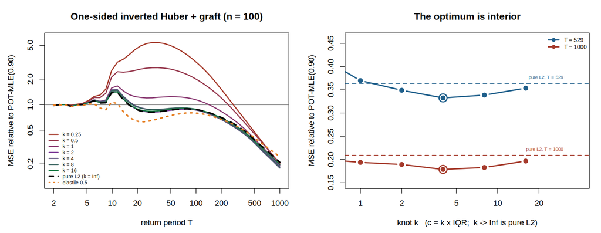

Figure 1. **The knot sweep under misspecification.** Left, MSE relative to peaks-over-threshold against return period for knots k = 0.25 to 16, with pure L2 (the k → ∞ limit) dashed and the α = 0.5 elastile dotted. Small knots are catastrophic below T = 200, the mechanism being Section 3.3. Right, the same numbers read along k: the optimum is interior at k = 4, circled, and the curve turns back towards the pure-L2 line on both sides.

### 5.3Under correct specification

None of the above is deployable without knowing what it costs when the family is right. We therefore repeat the study on data drawn from the fitted family exactly. On iid GEV(0, 1, 0.2) at n = 100, where maximum likelihood is efficient, the composite estimators lose (Table 4).

**Table 4.** MSE relative to the GEV MLE on data that really are GEV, n = 100, 2000 replicates. Above 1 is the price paid. The final column is the median fitted shape against a true ξ = 0.2.

| estimator | T=2 | T=10 | T=48 | T=203 | T=529 | T=1000 | median ξ̂ |
| --- | --- | --- | --- | --- | --- | --- | --- |
| GEV L-moments | 1.05 | 0.95 | 0.94 | 0.98 | 1.01 | 1.03 | 0.184 |
| composite L1 | 3.68 | 1.20 | 1.11 | 1.64 | 2.24 | 2.83 | 0.167 |
| composite L2 | 2.03 | 2.03 | 1.30 | 1.28 | 1.31 | 1.32 | 0.095 |
| α-elastile, α = 0.5 | 2.01 | 1.51 | 0.98 | 1.04 | 1.15 | 1.25 | 0.122 |
| one-sided, k = 4 | 2.47 | 2.28 | 1.43 | 1.26 | 1.18 | 1.12 | 0.085 |
| GEV MLE | 1.00 | 1.00 | 1.00 | 1.00 | 1.00 | 1.00 | 0.198 |

Three readings. The body is where the loss hurts: every composite estimator is two to nearly four times the MLE's error at T = 2, the weight doing precisely what it was told in a setting where the body was informative. The far-tail premium is modest for two members — 12% for the one-sided loss and 25% for the elastile — which is a defensible insurance cost. And the composite quantile estimator gets *worse* with return period rather than better, 1.11 at T = 48 rising to 2.83 at T = 1000: its variance penalty appears with no misspecification to justify it. That penalty is finite-sample and should not be read as a verdict on the loss — Section 3.2 gives the pinball loss the wider domain and Section 6.1 the same reach–efficiency frontier as the asymmetric square. At n = 100 it is the worse choice; asymptotically it is not.

**The bias runs in the unsafe direction.** At T = 1000 the MLE is biased +1.01 and L-moments +0.45, while the composite expectile is −1.52 and the one-sided loss −1.93. The composite estimators under-predict the far tail, which for design purposes is the dangerous direction. The cause is in the last column of Table 4: tail-weighted fitting underestimates the shape parameter badly at n = 100 even with a perfect family, and a low shape shrinks the extrapolation.

**Table 5.** MSE relative to GPD L-moments on data that really are GPD, threshold known, n = 100. All rows grafted. Below 1 is better than L-moments. The second row gives the corresponding return period when the GPD sits above a threshold with exceedance rate ζ = 0.1.

| estimator | T=2 | T=5 | T=10 | T=26 | T=48 | T=107 | T=1000 |
| --- | --- | --- | --- | --- | --- | --- | --- |
| ζ = 0.1: true return period | 20 | 52 | 98 | 256 | 484 | 1074 | 10<sup>4</sup> |
| GPD MLE | 1.06 | 1.00 | 1.03 | 1.09 | 1.12 | 1.15 | 1.20 |
| empirical distribution alone | 1.43 | 1.51 | 1.59 | 1.55 | 1.44 | 1.33 | 1.05 |
| composite L1 | 1.36 | 1.36 | 1.26 | 1.21 | 1.25 | 1.32 | 1.51 |
| composite L2 | 1.36 | 1.35 | 1.19 | 1.00 | 0.98 | 1.00 | 0.97 |
| α-elastile, α = 0.5 | 1.35 | 1.36 | 1.21 | 1.03 | 1.02 | 1.03 | 1.01 |
| one-sided, k = 4 | 1.36 | 1.35 | 1.19 | 0.98 | 0.94 | 0.91 | 0.76 |

The cost is confined to short return periods (Figure 2). Against the MLE the one-sided estimator is 1.29 at T = 2 and 1.34 at T = 5, but it crosses below one by about T = 26 and reaches **0.63 at T = 1000** — a 37% improvement on the efficient estimator with nothing misspecified. Against L-moments, the stiffer benchmark, the same estimator runs 1.36, 1.35, 1.19, 0.98, 0.94, 0.91, 0.76 across the columns. So there is no far-tail premium here at all: the tail-weighted criteria beat both conventional estimators where the extrapolation matters, and pay for it only near the threshold. Under a peaks-over-threshold reading with ζ = 0.1 the crossing at T = 26 is the 260-year level, so the range in which the method loses is the lower part of the design range rather than the whole of it.

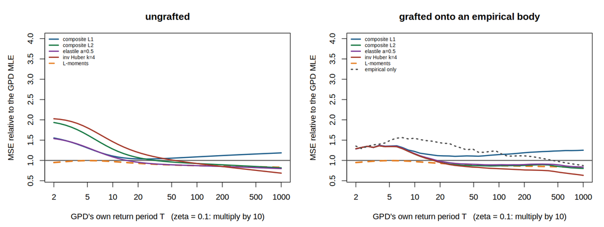

Figure 2. **The premium, on a correctly specified GPD.** Threshold known, so every method estimates the same two parameters. Left, ungrafted: the composite fits are 1.5 to 2.0 times the MLE at T = 2 because the weight neglected the body. Right, grafted onto an empirical body, which brings all four to about 1.29 there — the same value for four different tail models, close to the empirical distribution's own 1.35 (dotted), because the body is doing the work. L-moments, dashed, beats the MLE throughout.

### 5.4Decomposing the apparent gain

The correctly-specified GPD study also exposes a confound that we believe is general. Compared against peaks-over-threshold with maximum likelihood at a 0.90 threshold — the conventional reference — the composite estimators win comfortably in the far tail on the contaminated truth, at an MSE ratio of 0.209 at T = 1000. But they also win with *no misspecification at all*, at a ratio of 0.344. The reason is that at n = 100 a 0.90 threshold leaves ten exceedances to fit two parameters, while the composite estimators use all one hundred observations; measured against an efficient full-sample estimator, POT–MLE(0.90) is itself 2.58 times worse at T = 1000 despite being correctly specified.

The decomposition

On a log scale, **68% of the apparent gain over the conventional reference is present with a perfectly specified model**, and only 32% is attributable to the misspecification the method exists to exploit. The gain is real, but it is mostly data efficiency, and a comparison reported only on a misspecified truth does not distinguish the two.

The remedy is cheap: report the same comparison on data simulated from the fitted family, and include a reference that does not discard observations. We would suggest this as routine for any proposal that claims to improve on peaks-over-threshold, since the threshold is doing work that is easily mistaken for the method's.

A related point concerns the shortest return periods. When the composite fit is grafted onto an empirical body, the T = 2 error is 1.284, 1.288, 1.283 and 1.289 for four very different tail models, and the empirical distribution alone gives 1.353. Four indistinguishable numbers indicate that the body is doing all the work: that column measures the empirical distribution against a parametric fit, and is a cost of grafting rather than of the loss.

### 5.5What the estimators converge to

The comparisons above are at a fixed sample size. Solving (4) removes the sampling noise and isolates what each criterion targets. Fit to exceedances over u = 3.16, the truth's 0.90-quantile, where threshold stability fixes the asymptotic target: if exceedances over u₀ are GPD(σ₀, ξ), then over u they are GPD(σ₀ + ξ(u − u₀), ξ), so for a GEV(μ, σ, ξ) tail the limiting GPD at u has shape ξ and scale σ + ξ(u − μ) — here (1.6323, 0.2000). The truth's conditional survival matches that to a maximum log-ratio of 2.7×10<sup>−7</sup> at u = 100.

**Table 6.** Pseudo-true GPD limits above u = 3.16 with w(p) = p<sup>6</sup>, solved from (4) to a residual below 10<sup>−10</sup>. The likelihood limit minimises Kullback–Leibler divergence and the L-moment limit matches the first two L-moments; both are obtained exactly. The right-hand block sweeps the weight for the asymmetric square.

| estimator | scale | shape | w = p<sup>m</sup> | scale | shape |
| --- | --- | --- | --- | --- | --- |
| POT maximum likelihood | 1.1933 | 0.3459 | m = 0 | 1.313 | 0.2637 |
| POT L-moments | 1.2011 | 0.3247 | m = 1 | 1.346 | 0.2520 |
| composite, pinball | 1.3804 | 0.2548 | m = 2 | 1.367 | 0.2448 |
| composite, asymmetric square | 1.4100 | 0.2316 | m = 6 | 1.410 | 0.2316 |
| α-elastile, α = 0.5 | 1.4090 | 0.2326 | m = 10 | 1.430 | 0.2259 |
| one-sided, k = 4 | 1.4176 | 0.2291 | m = 20 | 1.455 | 0.2195 |
| limiting GPD (the target) | 1.6323 | 0.2000 | → limit | 1.632 | 0.2000 |

Three readings. Maximum likelihood and L-moments do *not* share a limit, 0.3459 against 0.3247: under correct specification they coincide, but under misspecification a Kullback–Leibler projection and a moment match are different functionals. ψ separates the losses only weakly — the asymmetric square, elastile and one-sided limits fall within 0.003 of each other, while the pinball sits 0.023 away, so the division that matters is bounded against unbounded ψ, not the choice among the unbounded ones. And the weight moves the target monotonically towards the limiting GPD, which is the asymptotic content of tail weighting: what section 3.3 costs in finite samples, this buys in the limit, and the tension between them is what fixes a usable weight.

One further decomposition is worth separating, and it is sharper than we expected. At m = 0 — a flat weight, no tail focus at all — the asymmetric square reaches 0.2637 against likelihood's 0.3459, so roughly half the movement from 0.346 to the limiting 0.200 is already achieved before any weighting is applied. The pinball loss at the same flat weight reaches 0.3448, which is likelihood's answer to three figures. **The early movement is therefore attributable entirely to the change of matched functional, and not at all to the composite construction itself** — a different argument from the one the method is usually motivated by, and one that Section 6.1 recovers independently in the effective threshold.

A caution on reading the target. The carried-back limiting GPD is not the truth's conditional law even asymptotically: conditioning on X > u sweeps in the body mass the contamination adds at the threshold, so S<sub>cond</sub>/S<sub>limit</sub> → 1/[S(u)(1 + ξu/σ)<sup>1/ξ</sup>] = 0.8629 here. The limit is a target for the shape; the truth is the target for the level.

### 5.6Against a weighted likelihood

The closest existing method is Fung's (2022) maximum weighted likelihood estimator, which tilts the likelihood rather than the loss. For a model density h and a non-decreasing weight ω bounded away from zero, MWLE maximises

ℓ(θ) = Σ<sub>i</sub> ω(y<sub>i</sub>) log h(y<sub>i</sub>; θ) − [Σ<sub>i</sub> ω(y<sub>i</sub>)] log C(θ), C(θ) = ∫ h(u; θ) ω(u) du

(12)

The normaliser makes (12) a genuine log-likelihood for the tilted density hω/C, so under misspecification it converges to a Kullback–Leibler projection taken in the tilted metric — a tail-weighted version of the same target maximum likelihood aims at. It is therefore a direct competitor rather than a related idea, and a comparison is owed.

The two weights live on different axes: ω acts on the observed value, w on the probability level. We bridge them through the quantile transform, setting ω(y) = ε + (1 − ε) w(F̂<sub>n</sub>(y)) with ε = 10<sup>−3</sup> for Fung's positivity requirement. The normaliser is then exact rather than quadrature: with ω constant between consecutive order statistics, C(θ) = Σ<sub>j</sub> ω<sub>j</sub> [H(y<sub>(j+1)</sub>; θ) − H(y<sub>(j)</sub>; θ)]. Setting w ≡ 1 recovers the ordinary maximum likelihood estimator to five decimal places in both families.

**Table 7.** GEV family, n = 100, 2000 replicates, MSE relative to the GEV maximum likelihood estimator. Left block, the contaminated truth of Section 5.1; right block, exactly correct GEV(0, 1, 0.2). The last column is the median fitted shape under contamination against a true ξ = 0.2.

| estimator | contaminated T=2 | contaminated T=48 | contaminated T=1000 | correct T=2 | correct T=48 | correct T=1000 | ξ̂ |  |
| --- | --- | --- | --- | --- | --- | --- | --- | --- |
| GEV maximum likelihood | 1.00 | 1.00 | 1.00 | 1.00 | 1.00 | 1.00 |  | 0.054 |
| GEV L-moments | 1.24 | 1.30 | 1.11 | 1.05 | 0.94 | 1.03 | 0.095 |  |
| MWLE, Fung (2022) | 32.50 | 2.62 | 0.86 | 43.14 | 1.25 | 1.05 | 0.224 |  |
| composite, asymmetric square | 4.83 | 1.71 | 1.04 | 2.03 | 1.30 | 1.32 | 0.189 |  |
| one-sided, k = 4 | 6.11 | 1.85 | 0.89 | 2.47 | 1.43 | 1.12 | 0.168 |  |

The peaks-over-threshold setting reverses the conclusion.

**Table 8.** GPD family, n = 100. Left block, exceedances over the sample 0.90-quantile of the contaminated truth, three parameters, relative to POT–MLE(0.90). Right block, exactly correct GPD(0, 0.5, 0.2) with the threshold known, two parameters, relative to the GPD MLE. Rows are grafted onto an empirical body except where marked ungrafted; the two reference rows are not grafted.

| estimator | contaminated, POT T=2 | contaminated, POT T=48 | contaminated, POT T=1000 | correct GPD T=2 | correct GPD T=48 | correct GPD T=1000 |
| --- | --- | --- | --- | --- | --- | --- |
| reference (POT–MLE / GPD MLE) | 1.00 | 1.00 | 1.00 | 1.00 | 1.00 | 1.00 |
| GPD L-moments | — | — | — | 0.95 | 0.89 | 0.83 |
| MWLE, ungrafted | — | — | — | 16.34 | 1.17 | 1.03 |
| MWLE, Fung (2022), grafted | 0.97 | 0.90 | 0.23 | 1.31 | 1.04 | 1.41 |
| composite, asymmetric square, grafted | 0.98 | 0.86 | 0.21 | 1.29 | 0.87 | 0.80 |
| one-sided, k = 4, grafted | 0.98 | 0.89 | 0.18 | 1.29 | 0.84 | 0.63 |

Fitting a two-parameter GPD above a known threshold, MWLE buys nothing: 0.99 to 1.03 from T = 200 outward, which is the neutral result a tilted likelihood should give when the untilted one is already efficient on a regular problem. The one-sided loss reaches 0.63 in the same comparison, and under contamination the composite estimators edge ahead as well. The two studies together suggest that the tilted likelihood's advantage is efficiency recovered on a hard estimation problem — the three-parameter GEV, whose shape is poorly identified — and that on a regular problem where no efficiency is available, what remains to be won is the choice of which discrepancy to minimise, where the composite criteria are better placed. We stress that this is one data-generating process in each family and offer the reading as a hypothesis.

Grafting behaves differently for the two. It improves every composite fit in both body and tail, and improves MWLE's body while *worsening* its tail, 1.03 to 1.41. The graft rescales the fitted survival by its own value at the join, so it inherits the noise in S<sub>θ̂</sub>(u); MWLE's pointwise weight leaves that quantity almost unconstrained, whereas a composite criterion still integrates over levels below the join with small but non-zero weight.

## 6The effective threshold

Penultimate approximation supplies the frame this construction has been missing. The extreme-value family is never exactly right at a finite level, and the shape best describing the data varies with how far out one looks (Fisher and Tippett, 1928; Gomes and de Haan, 1999). A tail-weighted estimator fitted above a low threshold is therefore not doing something the threshold framework cannot express: it is behaving *as if* handed a higher threshold, and the question is which one.

The coordinate that makes this precise is the reciprocal hazard r(x) = S(x)/f(x). A GPD anchored at u has r(u+y) = σ + ξy exactly — a straight line whose intercept is the scale and whose slope is the shape. So for any distribution r(x) is the penultimate scale at level x, r′(x) the penultimate shape, and lim r′ the ultimate shape. Fitting a GPD is fitting a line through r, and estimators differ only in where along r they read.

effective threshold: the return period R = 1/S(x<sub>e</sub>) at which r′(x<sub>e</sub>) = ξ* kernel: ξ* = ∫ K(s) r′(u+s) ds, K ≥ 0, ∫K = 1

(13)

ξ* is the pseudo-true shape of Section 2.3, so the effective threshold is the level whose local penultimate shape equals what the estimator actually returns; the kernel says which band of the tail that average is taken over. K is recovered without assuming the representation holds, by perturbing r with a smooth *step* at position s — a unit-mass bump in r′ there — and reading K(s) = ∂ξ*/∂ε. The construction is due to a companion study of smooth grafting, which applied it to maximum likelihood, weighted composite likelihood and Luceño's AD2R; our implementation reproduces its published figures for maximum likelihood (effective threshold 12.7–15.5 against 13–16; kernel 10% point 6.3–6.8 against 6.5) and passes its consistency check, that the target's own scale agrees with the penultimate GPD at x<sub>e</sub> carried back to u, to 4%.

### 6.1Where the family sits, and what it costs

Everything below is population-level quadrature against a known distribution. Fitting is above R = 4 throughout. Because Section 2.4 gives the asymptotic variance in the same closed form, the two can be put on one axis: what does each unit of reach cost in efficiency?

**Table 9.** The reach–efficiency frontier. Effective threshold on the misspecified GEV(0, 1, 0.2) tail; asymptotic sd of √n ξ̂ from (8) on a correctly specified GPD(0, 1, 0.2), relative to the GPD maximum likelihood estimator's exact 1 + ξ.

| estimator | effective threshold | sd(√n ξ̂) | relative to MLE |
| --- | --- | --- | --- |
| GPD maximum likelihood | 14.0 | 1.200 | 1.00 |
| pinball, w = 1 | 11.6 | 1.315 | 1.10 |
| pinball, w = p⁶ | 17.9 | 1.420 | 1.18 |
| pinball, w = p²⁰ | 26.9 | 1.765 | 1.47 |
| asymmetric square, w = 1 | 18.6 | 1.384 | 1.15 |
| asymmetric square, w = p² | 22.5 | 1.562 | 1.30 |
| asymmetric square, w = p⁶ | 27.5 | 1.808 | 1.51 |
| **asymmetric square, w = p⁸** | **29.4** | **1.903** | **1.59** |
| asymmetric square, w = p²⁰ | 37.3 | 2.316 | 1.93 |
| **one-sided, k = 4, w = p⁶** | **29.0** | **1.965** | **1.64** |

**Most of the reach is not the weight.** The asymmetric square with a *flat* weight already reads the 18.6-year level against maximum likelihood's 14.0, for a 15% variance premium — before any tail focus is applied. Changing the matched functional from a likelihood to an expectile does more than the weight then does. This is the same decomposition Table 6 showed in the pseudo-true limits, and it is not how the construction is usually motivated, including by us.

**The pinball loss moves the reading point the wrong way, but is not thereby inefficient.** With a flat weight it reads the 11.6-year level — *below* maximum likelihood — while costing 10% more variance, so at that weight it is dominated on both axes at once. It takes w = p²⁰ to drag it to 26.9, where the asymmetric square needs only w = p⁶ to reach 27.5. But the weight is free, and what matters is the frontier rather than the label on it. Interpolating both curves and comparing at *matched* effective threshold, the ratio of the asymmetric square's asymptotic sd to the pinball loss's is 0.97 at R<sub>e</sub> = 20, 1.00 at 25, and 1.02 to 1.04 from 30 to 35: **the two losses trace the same reach–efficiency frontier to within 4%**, the asymmetric square marginally ahead at short reach and the pinball loss marginally ahead at long reach. Quantile matching pulls the reading point in and expectile matching pushes it out, but that says where the weight has to be set, not what the reach costs.

So the case for the asymmetric square does *not* rest on asymptotic efficiency. It rests on the finite-sample variance of the extrapolated return level at n = 100 (Section 5.2), and on the pseudo-true target: at a flat weight the asymmetric square already reaches shape 0.2637, while the pinball loss reaches 0.3448 — indistinguishable from likelihood's 0.3459. Matching quantiles with a flat weight targets what likelihood targets; matching expectiles does not. Against those, Table 3 gives the pinball loss an advantage the asymmetric square cannot have: it needs no moment condition, so it stays root-n for every ξ while the asymmetric square's variance diverges as ξ → 1/2. For a tail heavy enough, the pinball loss is the only member of the family still available.

The one-sided loss is asymptotically dominated

At k = 4 it reads the 29.0-year level with sd 1.965. The asymmetric square at w = p⁸ reads *further* — 29.4 — for **3% less variance**. Sharpening the weight on the plain L2 criterion achieves everything the knot achieves, more cheaply. Its asymptotic variance is also monotone decreasing in k towards the pure-L2 limit, which it attains to five decimals by k = 64, so the interior optimum at k = 4 reported in Section 5.2 has *no asymptotic counterpart*: it is a finite-sample effect, consistent with the one-sided loss's unusually slow convergence in Table 2. Proposition 2's estimator should be presented as an n = 100 finding, not as a better functional.

### 6.2Shift, or widen?

The exception is instructive. Fung's weighted likelihood reads the 43.5-year level — further than any composite estimator here — on a span of 30. Tilting a *likelihood* moves the reading point without smearing it; tilting a *loss* does both. We suspect this is the mechanism behind Section 5.6's efficiency result, where MWLE paid a 4–5% premium under correct specification against the composites' 12–32%. The pinball loss sits at the other extreme, with the narrowest kernel of anything examined (9 at a flat weight) and the least reach. Narrow-and-near, narrow-and-far, wide-and-far: the three are not three points on one dial.

### 6.3Is it cheaper than raising the threshold?

The comparison the construction exists to make. An estimator fitted above R = 4 that reads the tail at R<sub>e</sub> could be replaced by a hard threshold at R<sub>e</sub>, which would buy the same bias and discard most of the sample. Maximum likelihood has an effective threshold of its own — here R<sub>e</sub> ≈ 3.6 R<sub>nominal</sub> — so the equal-bias competitor to a composite estimator at R<sub>e</sub> = 27.5 is maximum likelihood at a *nominal* threshold of 7.7, not 27.5. Simulating on GEV(0, 1, 0.2) and matching on sampling standard deviation: at n = 5000 every composite estimator reaches its effective threshold for less variance than the threshold would need — the asymmetric square at w = p²⁰ matches maximum likelihood at a nominal 12.4 against the 10.4 required for equal bias, 19% further out — and at n = 1000 the ordering reverses.

The n = 1000 reversal should not be read as a property of the method. At that size none of these estimators is near its asymptotic target: mean ξ̂ runs 0.140 to 0.158 against targets of 0.177 to 0.189, so the matched-bias premise fails. At n = 5000 they are close (0.180 against 0.185) and the comparison means what it says. The practical consequence is uncomfortable and worth stating plainly: **the effective threshold is an asymptotic statement, and n = 100 — the sample size of Section 5 and of annual-maximum practice — is nowhere near where it becomes true.**

### 6.4Two limits of the diagnostic

**Non-monotone r′ leaves the number undefined.** LP3 — log X ~ Gamma(a, β), whose penultimate shape converges only logarithmically, r′(x) = β + β²(a−1)/log x — has, at β = 0.45, an r′ that rises from 0.459 at R = 4 to about 0.480 near R = 20 before decaying back over eight decades. The equation r′(x) = ξ* then has two roots for any target inside that window, and 51 of the 52 estimator cells on those populations report multiple crossings. The kernel remains well defined; the summary number does not. Any effective-threshold table needs a monotonicity check attached.

**The linear representation holds only to about 5%.** ∫K = 1 is exact only if ξ* is genuinely a linear functional of the local shapes. Measured, it is 0.99–1.01 for maximum likelihood and MWLE but 1.04–1.07 for every composite estimator, and the gap is the estimator rather than the quadrature: perturbing r′ by a constant c shifts ξ* by 1.006c for maximum likelihood and 1.048c for the asymmetric square, the same number by an independent route. The kernel quantiles quoted above are renormalised accordingly, and are sound for reading location and width but not for arithmetic.

## 7Discussion

Tail-weighted composite losses do what they are designed to do. Under body misspecification of the kind that rain-on-snow catchments produce, they remove essentially all of the asymptotic bias that likelihood and L-moments incur, and the change from the pinball loss to the asymmetric square removes most of the variance penalty that made the L1 construction unattractive. The one-sided influence function of Proposition 2 is the most accurate far-tail member of the family at n = 100, and it has the distinction of being derived from the obstacle rather than interpolated between two existing losses — though Section 6.1 shows that advantage does not survive to the limit.

Five qualifications should travel with that conclusion.

First, what the method costs when nothing is wrong depends sharply on the setting, and the two correctly-specified studies here disagree. Fitting a GEV to block maxima it costs 12–32% in the far tail and two to four times in the body. Fitting a GPD to exceedances it costs nothing in the far tail — the one-sided estimator reaches 0.63 against the MLE and 0.76 against L-moments at T = 1000 — and the cost is confined to short return periods. We do not think either number should be quoted as the premium: the difference between them is the fitting setup, and the honest summary is that the cost is concentrated near the threshold in both, while the far-tail behaviour depends on the configuration. The question a practitioner must answer first is still whether the body model is wrong, which for a catchment with two flood-generating mechanisms is a physical argument rather than a statistical one.

Second, the errors run the wrong way for design. Every composite estimator we examined under-predicts the far tail when the model is correct, because tail-weighted fitting underestimates the shape parameter at realistic sample sizes. Where the consequence of under-prediction is asymmetric — as it is for flood defence — this may outweigh a modest MSE advantage, and an explicit bias correction or a shrinkage-aware reporting convention would be worth developing.

Third, and most consequential for the literature, the conventional comparison overstates the case. Two thirds of the apparent advantage over peaks-over-threshold in our misspecified study is present when nothing is misspecified, because the reference discards nine tenths of the sample. We do not think this is peculiar to our estimators; any whole-sample method compared against a high-threshold POT fit will inherit the same advantage, and the practice of reporting only the misspecified comparison makes it invisible.

Fourth, the closest existing method is ahead of ours in one of the two settings we tried. Section 5.6 puts Fung's weighted likelihood at the lowest far-tail error on the three-parameter GEV and at a far smaller premium under correct specification, while the composite criteria lead on the two-parameter GPD above a known threshold. We take the reading that a tilted likelihood recovers efficiency where an untilted one leaves some on the table, and that on a regular problem where it does not, the choice of discrepancy is what remains — but this rests on one data-generating process in each family, and settling it needs a sweep over the shape, the sample size and the form of contamination. Any claim that a tail-weighted loss improves on tail-weighted likelihood should wait for that.

Fifth, and most uncomfortably, two of our central finite-sample findings reverse asymptotically. The headline comparison of Section 5.2 is that the asymmetric square beats the pinball loss two- to six-fold on far-tail mean squared error at n = 100; but by Proposition 3, at matched weight and on a correctly specified GPD(0, 1, 0.2), the pinball loss has the *lower* asymptotic variance for the shape — 1.42 against 1.81 — and it is lower for every ξ above about 0.06. And the interior optimum in the one-sided loss's knot disappears entirely in the limit, where its variance is monotone in k and the plain asymmetric square at a sharper weight dominates it (Section 6.1). Neither reversal invalidates the finite-sample results, which are what a hydrologist with a hundred annual maxima experiences. Both mean that the mechanism we have been attributing them to — a better functional — is wrong: what the asymmetric square and the knot buy at n = 100 is finite-sample stability, not asymptotic efficiency, and the paper should say so rather than let the reader infer otherwise.

A further direction is the interaction with penultimate approximation. This paper takes the extreme-value family as exactly correct in the tail and asks only how to protect that fit from the body; penultimate theory says the family is never exactly correct at a finite level, and that the shape best describing the data varies with how far into the tail one looks. A composite criterion that integrates over a range of levels therefore fits a single ξ across a region where the penultimate shape is not constant, which is a source of bias the present framework does not model. Allowing ξ to vary with p in a manner consistent with second-order regular variation would address both problems at once, and would also give a principled reason to weight the far tail more heavily than the near tail beyond the contamination argument — the tail model gets better as one moves out.

A last direction moves outside the M-estimator family altogether. Extremiles (Daouia, Gijbels and Stupfler, 2019) are L-functionals — the τ-extremile is the expected maximum of r(τ) = log ½ / log τ independent copies — so the composite loss does not generate them, but the other half of the construction does transfer: minimising a weighted distance between the empirical and model extremile functions gives a tail-weighted probability-weighted-moment estimator, whose natural comparison is Hosking and Wallis (1987) rather than maximum likelihood. Both extreme-value families have closed-form extremiles. In our study this estimator is the only one with no cost anywhere: at a short reach it matches the MLE in the body of a correctly specified GPD and removes 26% of the far-tail error, beating L-moments throughout, though it does not reach the composite estimators' gains under contamination. The reach must be an intermediate sequence — capping it at the sample size leaves the estimator inconsistent, since the empirical extremile then places most of its weight on the sample maximum.

Several other directions remain. The exponent of the loss can be varied continuously between one and two, giving the L<sup>a</sup>-quantiles; we found these dominated by the elastile on accuracy at every return period tested, but they are the only continuous path off the pinball loss that widens the admissible domain (Table 3), and are the natural recourse when ξ is too large for the asymmetric square to have a limit distribution. The mixing weight α may be made a function of the level while remaining proper, though the oracle ceiling for doing so is small. And the sandwich variance of Section 2.4, now derived and checked, has not been used for inference: the near-flat ridge that dominates the estimators' variance is A approaching singularity over the tail-weighted region, which suggests a reparameterisation or a penalty in that direction rather than a further change of loss, and leaves the interval coverage of Proposition 3 at realistic n an open question we have not addressed.

## 8References

1. **Basu, A., Harris, I. R., Hjort, N. L. and Jones, M. C.** (1998). Robust and efficient estimation by minimising a density power divergence. *Biometrika* **85**, 549–559.
2. **Bradic, J., Fan, J. and Wang, W.** (2011). Penalized composite quasi-likelihood for ultrahigh dimensional variable selection. *Journal of the Royal Statistical Society, Series B* **73**, 325–349.
3. **Breckling, J. and Chambers, R.** (1988). M-quantiles. *Biometrika* **75**, 761–771.
4. **Daouia, A., Gijbels, I. and Stupfler, G.** (2019). Extremiles: a new perspective on asymmetric least squares. *Journal of the American Statistical Association* **114**, 1366–1381.
5. **Dupuis, D. J.** (1998). Exceedances over high thresholds: a guide to threshold selection. *Extremes* **1**, 251–261.
6. **Fung, T. C.** (2022). Maximum weighted likelihood estimator for robust heavy-tail modelling of finite mixture models. *Insurance: Mathematics and Economics* **107**, 180–198.
7. **Fisher, R. A. and Tippett, L. H. C.** (1928). Limiting forms of the frequency distribution of the largest or smallest member of a sample. *Proceedings of the Cambridge Philosophical Society* **24**, 180–190.
8. **Gomes, M. I. and de Haan, L.** (1999). Approximation by penultimate extreme value distributions. *Extremes* **2**, 71–85.
9. **Hosking, J. R. M. and Wallis, J. R.** (1987). Parameter and quantile estimation for the generalized Pareto distribution. *Technometrics* **29**, 339–349.
10. **Huber, P. J.** (1964). Robust estimation of a location parameter. *Annals of Mathematical Statistics* **35**, 73–101.
11. **Juárez, S. F. and Schucany, W. R.** (2004). Robust and efficient estimation for the generalized Pareto distribution. *Extremes* **7**, 237–251.
12. **Koenker, R. and Bassett, G.** (1978). Regression quantiles. *Econometrica* **46**, 33–50.
13. **Newey, W. K. and Powell, J. L.** (1987). Asymmetric least squares estimation and testing. *Econometrica* **55**, 819–847.
14. **Waylen, P. and Woo, M.-K.** (1982). Prediction of annual floods generated by mixed processes. *Water Resources Research* **18**, 1283–1286.
15. **Zou, H. and Yuan, M.** (2008). Composite quantile regression and the oracle model selection theory. *Annals of Statistics* **36**, 1108–1126.